# 2018 Shootings Report

This report display the mass shooting incident data in 2018. In 2018, there are total 340 occured and 373 lives were taken in these incidents. By counting the total live lost and injured for each cities, I conclude that Chicago is most impacted by shooting incidents. Besides, I also discovered that California, Illinois have most shooting happened.

## The Table of Top Ten Cities of Shootings

[output not shown]

## Florida Shooting Incident

At February 14, 2018, a tragic mass shooting happened at high school in Pompano Beach (Parkland), Florida. The high school locates at 5901 Pine Island Rd, and a 19-year-old teen gunman [Nikolas Cruz](https://www.nbcnews.com/news/us-news/police-respond-shooting-parkland-florida-high-school-n848101) was accused for this mass shooting. In this mass shooting, there are 17 people were injured and 17 people were killed. In most news, the injured number were [14](https://www.foxnews.com/us/florida-school-shooting-timeline), and this trigic shooting began at [2:53pm and ended at 4:27pm](https://www.foxnews.com/us/florida-school-shooting-timeline). Through this mass shooting, the bloody data reflect the importance of gun control is necessary.

## Shootings Map

[interactive chart not shown]

The map provide clear visual representation base on geography, the size and color of circular markers indicates the total damage(injured number plus lost number) caused by each shooting, hover over or click marker for more information.

## Plot

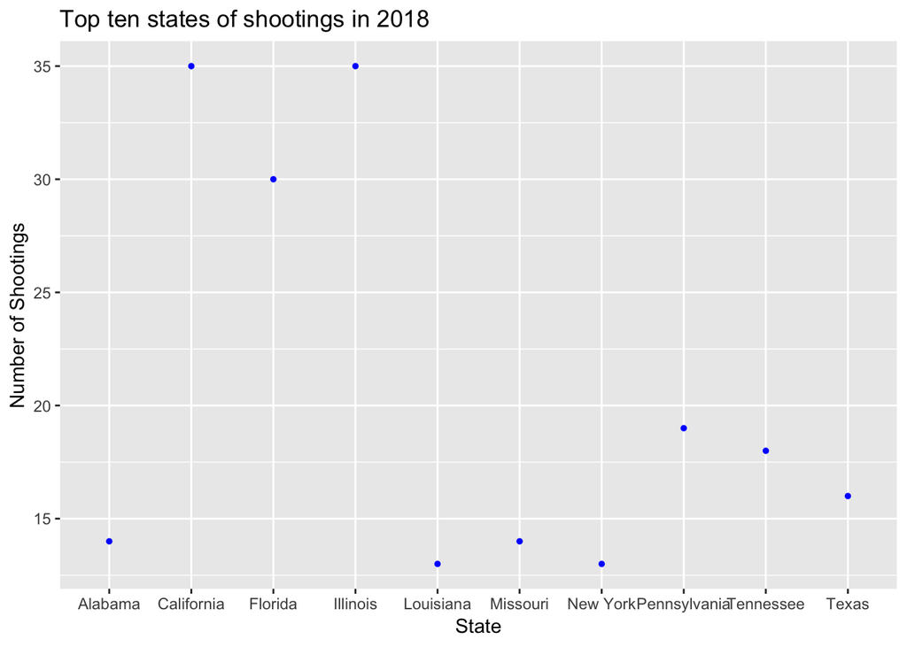

The gun control has been a long issue unsolved, people might wonder what are the states that suffered from shootings most. The plot reveals ten states that happened most shooting incidents in 2018. This urges those ten states’ people and governments putting more effort on gun control issue.